# ep11

15 de noviembre de 2022

#### 1. Definir la semilla a utilizar, que corresponde a los últimos cuatro dígitos del RUN (sin considerar el dígito verificador) del integrante de menor edad del equipo.

```r
# cargar datos
datos = read.csv2("EP11 Datos.csv")
set.seed(5900)
```

#### 2. Seleccionar una muestra de 50 mujeres (si la semilla es un número par) o 50 hombres (si la semilla es impar).

```r
# Se filtran los datos para que sean de género femenino
mujeres = datos[(datos$Gender == 0),]
# Se extrae una muestra de 50 mujeres dado que la semilla es par
n = nrow(mujeres)
muestra = sample.int(n = n, size = 50, replace = FALSE)
mujeres_c = mujeres[muestra,]
```

#### 3. Seleccionar de forma aleatoria ocho posibles variables predictoras.

```r
# Selección de 8 variables aleatorias
mujeres_r = sample(mujeres_c,8)
```

#### 4. Seleccionar, de las otras variables, una que el equipo considere que podría ser útil para predecir la variable Peso, justificando bien esta selección.

```r
# Al dataframe inicial, se le quitan las columnas que fueron seleccionadas aleatoriamente
variables <- c("Shoulder.Girth", "Chest.depth", "Biacromial.diameter", "Bicep.Girth", "Hip.Girth", "Waist.Girth", "Bitrochanteric.diameter", "Chest.diameter")
datos_2 <- mujeres_c[ , !(names(mujeres_c) %in% variables)]

# Se calcula el coeficiente de correlación para cada una de las variables
cor(datos_2, y = datos_2$Weight)
```

```
##                          [,1]
## Biiliac.diameter    0.5843807
## Elbows.diameter     0.7227331
## Wrists.diameter     0.6135850
## Knees.diameter      0.8749756
## Ankles.diameter     0.6790142
## Chest.Girth         0.8158618
## Navel.Girth         0.8046344
## Thigh.Girth         0.8782124
## Forearm.Girth       0.8835270
## Knee.Girth          0.8603753
## Calf.Maximum.Girth  0.8314165
## Ankle.Minimum.Girth 0.6592225
## Wrist.Minimum.Girth 0.6981918
## Age                 0.1957309
## Weight              1.0000000
## Height              0.6077793
## Gender                     NA
```

Como la variable que tiene mayor índice de correlación es “Forearm.Girth”, se escoge esta para poder predecir la variable “Weight”

#### 5. Usando el entorno R, construir un modelo de regresión lineal simple con el predictor seleccionado en el paso anterior.

## Including Plots

```
##
## Call:
## lm(formula = Weight ~ Forearm.Girth, data = mujeres_c)
##
## Residuals:
##     Min      1Q  Median      3Q     Max
## -9.2464 -2.5093 -0.3074  2.6517  9.2807
##
## Coefficients:
##               Estimate Std. Error t value Pr(>|t|)
## (Intercept)   -53.3643     8.6895  -6.141 1.53e-07 ***
## Forearm.Girth   4.7624     0.3644  13.069  < 2e-16 ***
## ---
## Signif. codes:  0 '***' 0.001 '**' 0.01 '*' 0.05 '.' 0.1 ' ' 1
##
## Residual standard error: 4.481 on 48 degrees of freedom
## Multiple R-squared:  0.7806, Adjusted R-squared:  0.776
## F-statistic: 170.8 on 1 and 48 DF,  p-value: < 2.2e-16
```

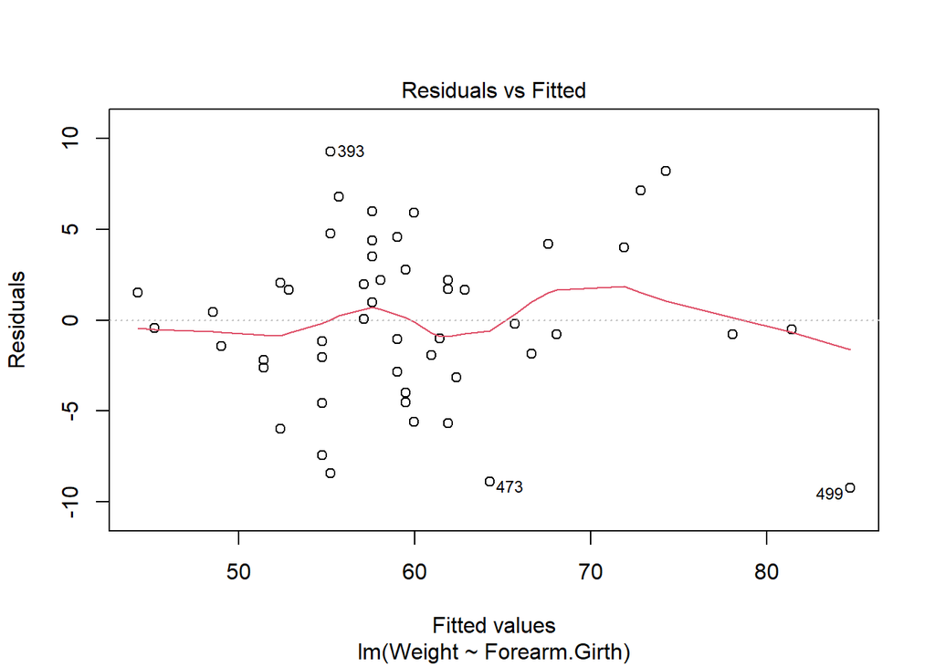

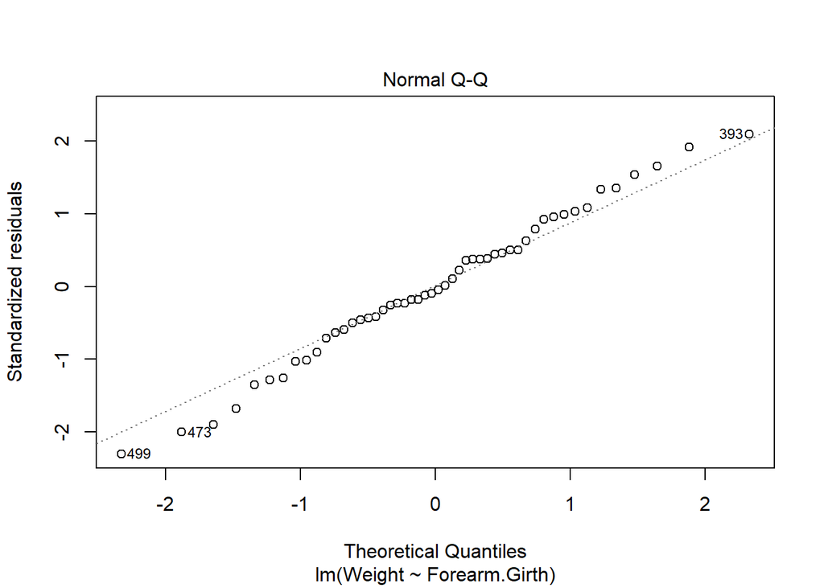

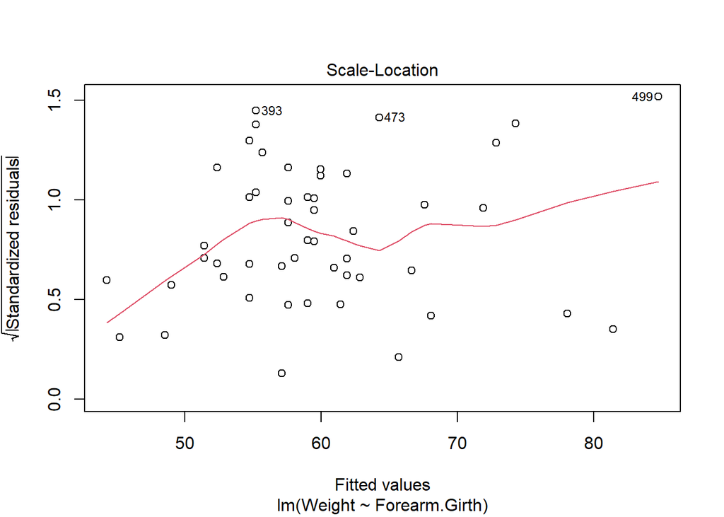

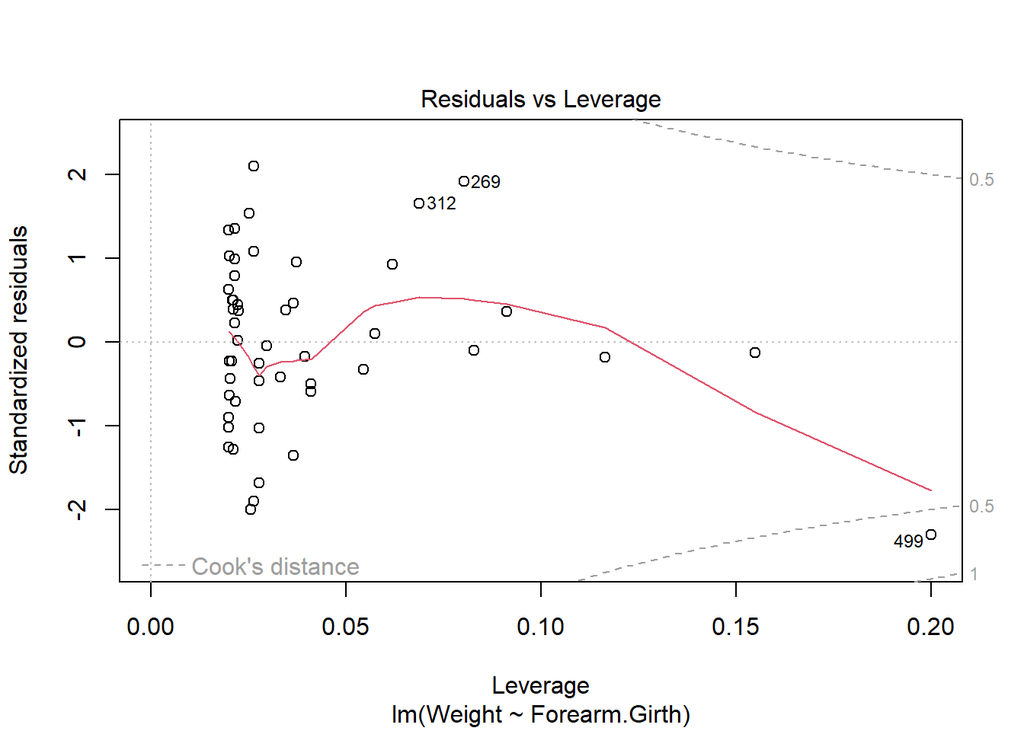

#### 6. Usando herramientas para la exploración de modelos del entorno R, buscar entre dos y cinco predictores de entre las variables seleccionadas al azar en el punto 3, para agregar al modelo de regresión lineal simple obtenido en el paso 5.

```r
# Se calcula la correlación entre la nueva variable y las 8 escogidas al azar.
cor(mujeres_r, y = datos_2$Forearm.Girth)
```

```
##                              [,1]
## Shoulder.Girth          0.6666464
## Chest.depth             0.5569083
## Biacromial.diameter     0.2813763
## Bicep.Girth             0.9148436
## Hip.Girth               0.7877598
## Waist.Girth             0.7345212
## Bitrochanteric.diameter 0.5898842
## Chest.diameter          0.4533915
```

```r
# Luego se calcula el AIC
ocho_variables = colnames(mujeres_r)
print(add1(modelo, scope = c(ocho_variables)))
```

```
## Single term additions
##
## Model:
## Weight ~ Forearm.Girth
##                         Df Sum of Sq    RSS    AIC
## <none>                               963.85 151.94
## Shoulder.Girth           1    193.25 770.59 142.76
## Chest.depth              1    163.86 799.99 144.63
## Biacromial.diameter      1     90.21 873.64 149.03
## Bicep.Girth              1     27.43 936.41 152.50
## Hip.Girth                1    598.59 365.25 105.43
## Waist.Girth              1    259.50 704.35 138.26
## Bitrochanteric.diameter  1    273.59 690.26 137.25
## Chest.diameter           1     99.35 864.50 148.51
```

###### El AIC de Hip.Girth es 105.43, pero la correlación con la nueva variable es de 0.7877598, por lo que se descarta. Por otro lado, la correlación de Chest.diameter es 0.4533915 y su AIC 148.51 por lo que se decide añadirla al modelo.

```r
modelo_2 = modelo
modelo_2 <- update(modelo_2, . ~ . + Chest.diameter)
print(modelo_2)
```

```
##
## Call:
## lm(formula = Weight ~ Forearm.Girth + Chest.diameter, data = mujeres_c)
##
## Coefficients:
##    (Intercept)   Forearm.Girth  Chest.diameter
##         -70.79            4.35            1.06
```

##### Para añadir otra variable, es necesario repetir el paso anterior pero con el nuevo modelo que contiene la variable recien añadida

```r
print(add1(modelo_2, scope = c(ocho_variables)))
```

```
## Single term additions
##
## Model:
## Weight ~ Forearm.Girth + Chest.diameter
##                         Df Sum of Sq    RSS    AIC
## <none>                               864.50 148.51
## Shoulder.Girth           1     97.51 766.99 144.52
## Chest.depth              1    170.25 694.25 139.54
## Biacromial.diameter      1     39.26 825.24 148.18
## Bicep.Girth              1     20.20 844.30 149.32
## Hip.Girth                1    510.35 354.15 105.89
## Waist.Girth              1    175.02 689.48 139.19
## Bitrochanteric.diameter  1    197.78 666.72 137.52
## Chest.diameter           0      0.00 864.50 148.51
```

##### Como la variable Bitrochanteric.diameter posee una correlación de 0.5898842 y su AIC es 137.52, se selecciona para añadirla al modelo

```r
modelo_2 <- update(modelo_2, . ~ . + Bitrochanteric.diameter)
print(modelo_2)
```

```
##
## Call:
## lm(formula = Weight ~ Forearm.Girth + Chest.diameter + Bitrochanteric.diameter,
##     data = mujeres_c)
##
## Coefficients:
##             (Intercept)            Forearm.Girth           Chest.diameter
##                -81.9846                   3.6667                   0.5454
## Bitrochanteric.diameter
##                  1.3017
```

##### Para añadir otra variable, es necesario repetir el paso anterior pero con el nuevo modelo que contiene la variable recien añadida

```r
print(add1(modelo_2, scope = c(ocho_variables)))
```

```
## Single term additions
##
## Model:
## Weight ~ Forearm.Girth + Chest.diameter + Bitrochanteric.diameter
##                         Df Sum of Sq    RSS    AIC
## <none>                               666.72 137.52
## Shoulder.Girth           1     81.71 585.02 132.98
## Chest.depth              1    138.54 528.18 127.87
## Biacromial.diameter      1      7.78 658.94 138.93
## Bicep.Girth              1     37.19 629.54 136.65
## Hip.Girth                1    320.81 345.92 106.71
## Waist.Girth              1    150.72 516.00 126.70
## Bitrochanteric.diameter  0      0.00 666.72 137.52
## Chest.diameter           0      0.00 666.72 137.52
```

```r
modelo_2 <- update(modelo_2, . ~ . + Bitrochanteric.diameter)
print(modelo_2)
```

```
##
## Call:
## lm(formula = Weight ~ Forearm.Girth + Chest.diameter + Bitrochanteric.diameter,
##     data = mujeres_c)
##
## Coefficients:
##             (Intercept)            Forearm.Girth           Chest.diameter
##                -81.9846                   3.6667                   0.5454
## Bitrochanteric.diameter
##                  1.3017
```

##### 7.Evaluar los modelos y “arreglarlos” en caso de que tengan algún problema con las condiciones que deben cumplir.

```r
# Comprobar independencia de los residuos
print("Prueba de Durbin-Watson para autocorrelaciones ")
```

```
## [1] "Prueba de Durbin-Watson para autocorrelaciones "
```

```r
print("entre errorres: ")
```

```
## [1] "entre errorres: "
```

```r
print(durbinWatsonTest(modelo_2))
```

```
##  lag Autocorrelation D-W Statistic p-value
##    1    0.0006658018      1.995785   0.982
##  Alternative hypothesis: rho != 0
```

##### podemos observar un p = 0.982 por lo que podemos asumir que existe independencia

```r
# Comprobar normalidad de los residuos
print("Prueba de normalidad para los residuos: ")
```

```
## [1] "Prueba de normalidad para los residuos: "
```

```r
print(shapiro.test(modelo_2$residuals))
```

```
##
##  Shapiro-Wilk normality test
##
## data:  modelo_2$residuals
## W = 0.99258, p-value = 0.9876
```

##### podemos observar un p = 0.9876 por lo que podemos asumir que existe normalidad en los residuos

```r
# Comprobar la homocedasticidad de los residuos
print("Prueba de homocedasticidad para los residuos:")
```

```
## [1] "Prueba de homocedasticidad para los residuos:"
```

```r
print(ncvTest(modelo_2))
```

```
## Non-constant Variance Score Test
## Variance formula: ~ fitted.values
## Chisquare = 1.010159, Df = 1, p = 0.31486
```

##### podemos observar un p = 0.31486 por lo que podemos asumir que el supuesto de homocedasticidad se cumple

```r
# Comprobar la multicolinealidad
vifs = vif(modelo_2)
print("Verificar la multicolinealidad: ")
```

```
## [1] "Verificar la multicolinealidad: "
```

```r
print("VIFS: ")
```

```
## [1] "VIFS: "
```

```r
print(vifs)
```

```
##           Forearm.Girth          Chest.diameter Bitrochanteric.diameter
##                1.615841                1.407646                1.715064
```

```r
print("Tolerancias :")
```

```
## [1] "Tolerancias :"
```

```r
print(1/vifs)
```

```
##           Forearm.Girth          Chest.diameter Bitrochanteric.diameter
##               0.6188727               0.7104060               0.5830686
```

```r
cat("- VIF medio: ", mean(vifs), "\n")
```

```
## - VIF medio:  1.579517
```

##### Todos los valores de VIF son menores a 10 por lo que no habría preocupacion a primera vista, incluso ocupando un criterio mas exijente de 5 no se ven valores preocupantes

##### Todas las tolerancias son mayores a 0,4 por lo que no tendriamos problemas

##### el VIF medio mayor a 1 indica un que se podria presenta un sesgo, por lo que se procedera a eliminar la variable predictivaBitrochanteric.diameter

##### esto ya que presenta el menor valor de p

```r
modelo_2 <- update(modelo_2, . ~ . - Bitrochanteric.diameter)
print(summary(modelo_2))
```

```
##
## Call:
## lm(formula = Weight ~ Forearm.Girth + Chest.diameter, data = mujeres_c)
##
## Residuals:
##     Min      1Q  Median      3Q     Max
## -9.0547 -2.2004 -0.1407  2.8860 11.1010
##
## Coefficients:
##                Estimate Std. Error t value Pr(>|t|)
## (Intercept)    -70.7905    11.1977  -6.322 8.75e-08 ***
## Forearm.Girth    4.3501     0.3913  11.117 9.41e-15 ***
## Chest.diameter   1.0596     0.4559   2.324   0.0245 *
## ---
## Signif. codes:  0 '***' 0.001 '**' 0.01 '*' 0.05 '.' 0.1 ' ' 1
##
## Residual standard error: 4.289 on 47 degrees of freedom
## Multiple R-squared:  0.8032, Adjusted R-squared:  0.7949
## F-statistic: 95.93 on 2 and 47 DF,  p-value: < 2.2e-16
```

##### una vez hecho esto se procede a reevaluar el cumplimiento de las condiciones

```r
# Comprobar independencia de los residuos
print("Prueba de Durbin-Watson para autocorrelaciones ")
```

```
## [1] "Prueba de Durbin-Watson para autocorrelaciones "
```

```r
print("entre errorres: ")
```

```
## [1] "entre errorres: "
```

```r
print(durbinWatsonTest(modelo_2))
```

```
##  lag Autocorrelation D-W Statistic p-value
##    1    -0.003714701      1.990806   0.988
##  Alternative hypothesis: rho != 0
```

##### podemos observar un p = 0.988 por lo que podemos asumir que existe independencia

```r
# Comprobar normalidad de los residuos
print("Prueba de normalidad para los residuos: ")
```

```
## [1] "Prueba de normalidad para los residuos: "
```

```r
print(shapiro.test(modelo_2$residuals))
```

```
##
##  Shapiro-Wilk normality test
##
## data:  modelo_2$residuals
## W = 0.98732, p-value = 0.8649
```

##### podemos observar un p = 0.8649 por lo que podemos asumir que existe normalidad en los residuos

```r
# Comprobar la homocedasticidad de los residuos
print("Prueba de homocedasticidad para los residuos:")
```

```
## [1] "Prueba de homocedasticidad para los residuos:"
```

```r
print(ncvTest(modelo_2))
```

```
## Non-constant Variance Score Test
## Variance formula: ~ fitted.values
## Chisquare = 0.06576454, Df = 1, p = 0.79761
```

##### podemos observar un p = 0.79761 por lo que podemos asumir que el supuesto de homocedasticidad se cumple

```r
# Comprobar la multicolinealidad
vifs = vif(modelo_2)
print("Verificar la multicolinealidad: ")
```

```
## [1] "Verificar la multicolinealidad: "
```

```r
print("VIFS: ")
```

```
## [1] "VIFS: "
```

```r
print(vifs)
```

```
##  Forearm.Girth Chest.diameter
##       1.258754       1.258754
```

```r
print("Tolerancias :")
```

```
## [1] "Tolerancias :"
```

```r
print(1/vifs)
```

```
##  Forearm.Girth Chest.diameter
##      0.7944362      0.7944362
```

```r
cat("- VIF medio: ", mean(vifs), "\n")
```

```
## - VIF medio:  1.258754
```

##### Todos los valores de VIF son menores a 10 por lo que no habría preocupacion a primera vista, incluso ocupando un criterio mas exijente de 5 no se ven valores preocupantes

##### Todas las tolerancias son mayores a 0,4 por lo que no tendriamos problemas

##### el VIF medio mayor a 1 indica un que se podria presenta un sesgo pero debido a la alta seguridad de los valores anteriores y al a cercania del valor se decidirá proceder con el modelo actual

##### 8.Evaluar el poder predictivo del modelo en datos no utilizados para construirlo (o utilizando validación cruzada).

```r
# Se extraen los datos no ocupados en el modelo
prueba = mujeres[-muestra,]

# Calcular error cuadrado promedio para datos de entrenamiento
mse_entrenamiento = mean(modelo_2$residuals ** 2)
cat("MSE para el conjunto de entrenamiento: ", mse_entrenamiento, "\n")
```

```
## MSE para el conjunto de entrenamiento:  17.29
```

```r
# Hacer predicciones para el conjunto de prueba
predicciones = predict(modelo_2,prueba)
# calcular error cuadrado promedio para el conjunto de prueba
error = prueba[["Weight"]] - predicciones
mse_prueba = mean(error ** 2)
cat("MSE para el conjunto de entrenamiento: ", mse_prueba, "\n")
```

```
## MSE para el conjunto de entrenamiento:  27.8668
```

##### se puede observar una diferencia mayor a 10 entre los errores cuadraticos medios por lo que no se recomienda que este modelo sea generalizable